# Genetic_Behaviour_Correlations

Alex Tsiofas

12/03/2021

```r
library(BiocManager)
library(dplyr)
library(genbankr)
library(rentrez)
library(annotate)
library(ape)
library(reshape2)
library(ggplot2)
library(ggtree)
```

The results of this study were consistent with those of Flint (2003) and Willis-Owen and Flint (2006) suggestings that many of the traits of interest were polygenic. However some strong associations of specific genes with traits were still uncovered.

One of the largest effect sizes was found with SNP CFA20 which was located very close to CADPS2- SNPs in this region were found to be correlated with the NoiseFear trait. Let’s generate an alignment and tree with species that have similar sequences to the Canis lupus familiaris CFA20 gene ## CADPS2 Alignment

```r
#pulling CADPS2 sequence from genbank
CAD_Lab <- GBAccession("XM_038687133.1")

#reading the genbank object
CAD_LabGBk <- readGenBank(CAD_Lab)
```

```
## Annotations don't have 'locus_tag' label, using 'gene' as gene_id column
## Annotations don't have 'locus_tag' label, using 'gene' as gene_id column
```

```
## No exons read from genbank file. Assuming sections of CDS are full exons
```

```
## No transcript features (mRNA) found, using spans of CDSs
```

```r
#blast searching the canis lupus CADPS2 sequence
BLASTSearch_CAD <- blastSequences(paste(CAD_LabGBk@sequence), as = 'data.frame', hitListSize = 40, timeout = 600)
```

```
## estimated response time 29 seconds
```

```r
#making a simple dataframe with just ID numbers and sequences
CADHitsDF <- data.frame(ID=BLASTSearch_CAD$Hit_def, Seq=BLASTSearch_CAD$Hsp_hseq, stringsAsFactors = FALSE)

#changing ID to just species name with regular expressions
CADHitsDF$ID <- gsub("PREDICTED: (.+) calcium.+", "\\1", CADHitsDF$ID)
CADHitsDF$ID <- gsub("PREDICTED: (.+) Ca.+", "\\1", CADHitsDF$ID)

#making sure theres no replicate hits from the same species
CADHitsDF <- CADHitsDF %>% distinct(ID, .keep_all = TRUE)

#turning the dataframe into a DNABin object by splitting the sequences so each nucleotide is its own string
CADHits <- sapply(CADHitsDF$Seq, strsplit, split="")

#adding species as the name
names(CADHits) <- CADHitsDF$ID

#then converting to a DNABin object
CADHits <- as.DNAbin(CADHits)

#Using Multiple Sequence Comparison by Log-Expectation (MUSCLE) to align the Canis lupus DRD4 sequence with the top blast searches
CAD_align <- muscle(CADHits)

#visualizing the alignment
checkAlignment(CAD_align, what = 1)
```

```
##
## Number of sequences: 16
## Number of sites: 3644
##
## Some gap lengths are not multiple of 3: 1
##
## Frequencies of gap lengths:
##  1  3  9 15
## 12  1  2 15
##    => no gap on the left border of the alignment
##    => length of gaps on the right border of the alignment: 1 1 1 1 1 1 1 1 1 1 1 1
##
## Number of unique contiguous base segments defined by gaps: 8
## Number of segment lengths not multiple of 3: 5
##     => on the left border of the alignement: 2
##     => on the right border                 : 1
##     => positions of these segments inside the alignment: 3060..3067 1618..2332
##
## Number of segregating sites (including gaps): 531
## Number of sites with at least one substitution: 499
## Number of sites with 1, 2, 3 or 4 observed bases:
##    1    2    3    4
## 3113  458   39    2
```

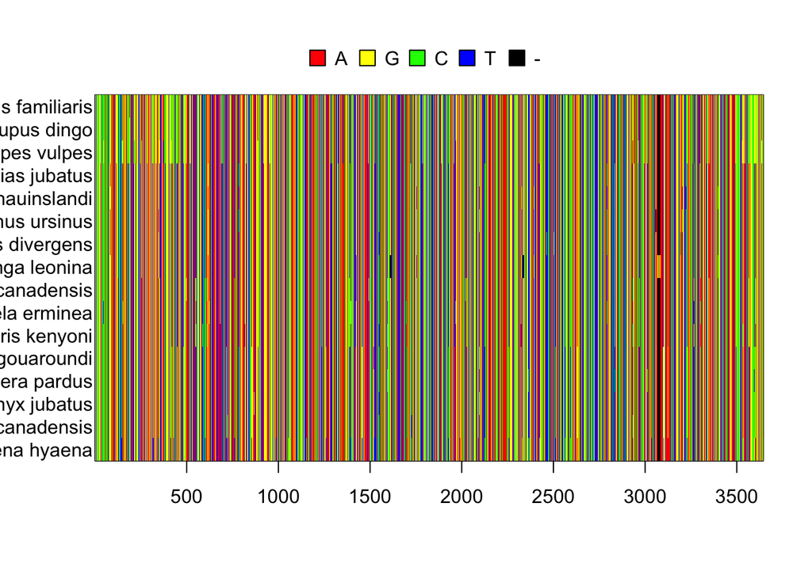

### CADPS2 Visualization

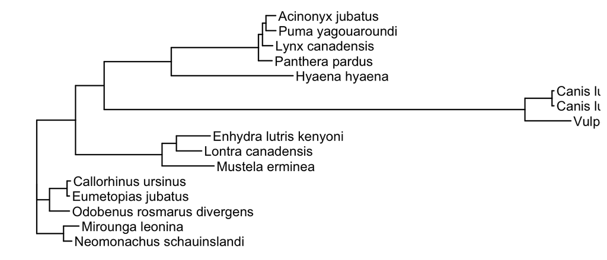

```r
#generating a distance matrix from the alignment
CAD_DM <- dist.dna(CAD_align, model = "K80")

#making a neighbour joining tree from the distance matrix
CAD_Tree <- njs(CAD_DM)

#visualizing the tree
CAD_treeim <- ggtree(CAD_Tree, layout = "rectangular")+
  geom_tiplab()
CAD_treeim
```

```r
#exporting the tree as a pdf
ggsave(filename = "CADtree.png", CAD_treeim, device = "png", width = 20, height = 4, units = "in" , limitsize = FALSE)

#creating a tree with no branch lengths
CAD_nodist <- ggtree(CAD_Tree, layout = "rectangular", branch.length = "none")+
  geom_tiplab()+
  xlim(NA, 24)

#exporting the no branch length tree as a pdf
ggsave(filename = "CADtree_nodist.png", CAD_nodist, device = "png", width = 5, height = 4, units = "in" , limitsize = FALSE)
```

Interestingly, after Canis lupus dingo, the closest animal to the domestic dog based on this tree is vulpes vulpes, the red fox. Malkemper et al. (2015) studied hearing sensitivity in red foxes and found that frequency cut offs were comparable to the domestic dog. A study of CADPS2 knockouts in mice showed an increase in fear and anxiety (Sadakata et al. 2007). This gene seems to play a key role in behaviour and may also be linked to hearing in many species. Other species in this tree could be investigated for noise fear behaviours and how SNPs in this gene may impact this trait.

## DRD4 Alignment

This next alignment is of dopamine receptor D4 (DRD4). DRD4 is a dopaminergenic receptor and polymorphisms in this regions have been found to be associated with inattention in many animals, including humans where variants of this gene have been connected to Attention Deficit/Hyperactivity Disorder of ADHD (Tovo-Rodriguez et al. 2013).

DRD4 and TH were both found to be associated with impulsivity and inattention. This finding is confirmed by Wan et al. (2013) in their study of Siberian Huskies.

```r
#Pulling DRD4 Sequence from GenBank and reading it
DRD4_Lab <- GBAccession("XM_038424041.1")
DRD4_LabGBk <- readGenBank(DRD4_Lab)
```

```
## Annotations don't have 'locus_tag' label, using 'gene' as gene_id column
## Annotations don't have 'locus_tag' label, using 'gene' as gene_id column
```

```
## No exons read from genbank file. Assuming sections of CDS are full exons
```

```
## No transcript features (mRNA) found, using spans of CDSs
```

```r
#Blast search to find close sequences to Canis lupus familiaris DRD4 Sequence
BLASTSearch_DRD4 <- blastSequences(paste(DRD4_LabGBk@sequence), as = 'data.frame', hitListSize = 20, timeout = 600)
```

```
## estimated response time 12 seconds
```

```r
#making a simple dataframe with just ID numbers and sequences
DRD4HitsDF <- data.frame(ID=BLASTSearch_DRD4$Hit_def, Seq=BLASTSearch_DRD4$Hsp_hseq, stringsAsFactors = FALSE)

#changing ID to just species name with regular expressions
DRD4HitsDF$ID <- gsub("PREDICTED: (.+) dopamine.+", "\\1", DRD4HitsDF$ID)
DRD4HitsDF$ID <- gsub("(.+)dopamine.+", "\\1", DRD4HitsDF$ID)

#making sure theres no replicate hits from the same species
DRD4HitsDF <- DRD4HitsDF %>% distinct(ID, .keep_all = TRUE)

#turning the dataframe into a DNABin object by splitting the sequences so each nucleotide is its own string
DRD4Hits <- sapply(DRD4HitsDF$Seq, strsplit, split="")

#adding species as the name
names(DRD4Hits) <- DRD4HitsDF$ID

#then converting to a DNABin object
DRD4Hits <- as.DNAbin(DRD4Hits)

#Using Multiple Sequence Comparison by Log-Expectation (MUSCLE) to align the Canis lupus DRD4 sequence with the top blast searches
DRD4_align <- muscle(DRD4Hits)

checkAlignment(DRD4_align, what = 1)
```

```
##
## Number of sequences: 18
## Number of sites: 531
##
## Some gap lengths are not multiple of 3: 1
##
## Frequencies of gap lengths:
##  1
## 16
##    => length of gaps on the left border of the alignment: 1
##    => no gap on the right border of the alignment
##
## Number of unique contiguous base segments defined by gaps: 1
## Number of segment lengths not multiple of 3: 1
##     => on the left border of the alignement: 0
##     => on the right border                 : 1
##
## Number of segregating sites (including gaps): 78
## Number of sites with at least one substitution: 78
## Number of sites with 1, 2, 3 or 4 observed bases:
##   1   2   3   4
## 453  68   9   1
```

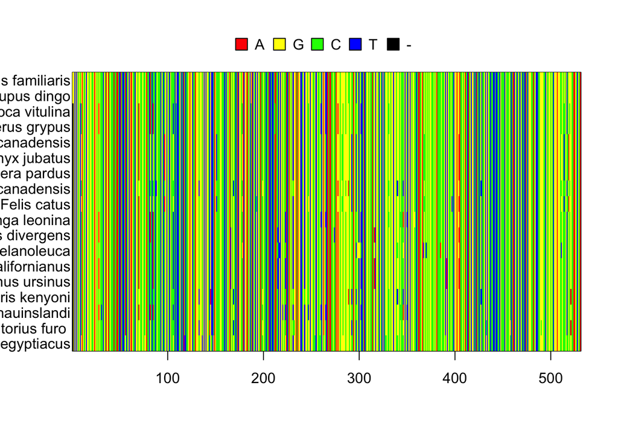

### DRD4 Visualization

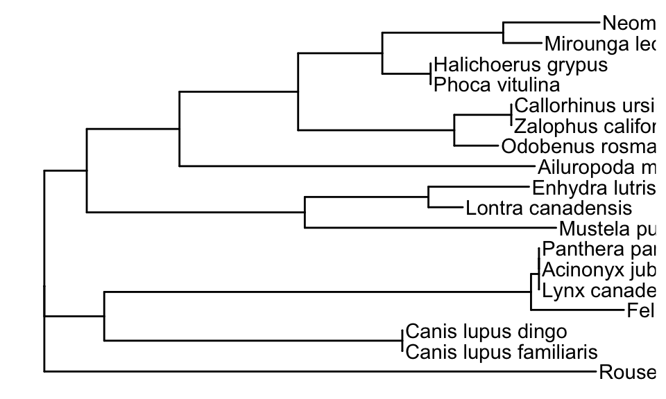

```r
#using the alignment to create a DNA distance matrix
DRD4_DM <- dist.dna(DRD4_align, model = "K80")

#using the distance matrix to create a neighbour joining tree
DRD4_Tree <- njs(DRD4_DM)

#generating the tree image as an object
Dr_treeim <- ggtree(DRD4_Tree, layout = "rectangular")+
  geom_tiplab()

Dr_treeim
```

```r
#exporting the tree image as a png
ggsave(filename = "DRD4tree.png", Dr_treeim, device = "png", width = 20, height = 4, units = "in" , limitsize = FALSE)

#generating a tree that doesnt make the branch lengths a factor
DR_nodist <- ggtree(DRD4_Tree, branch.length = "none")+
  geom_tiplab()+
  xlim(NA, 24)

#exporting the tree without distance
ggsave(filename = "DRD4tree_nodist.png", DR_nodist, device = "png", width = 8, height = 4, units = "in" , limitsize = FALSE)
```

This tree puts the domestic cat much closer to the dog, indicating that similarities could have been caused in the domestication process. This makes sense as non-impulsivity and good attention span would be a positive trait in domesticated animals.

## TH Alignment

The final gene investigated encodes tyrosine hydroxylase (TH). TH is an enzyme involved in the dopamine synthesis pathway and has also been associated with inattention and impulsivity.

```r
#Pulling TH Sequence from GenBank
THLab <- GBAccession("AB097058.1")

#reading the genbank object
THLabGBk <- readGenBank(THLab)
```

```
## Annotations don't have 'locus_tag' label, using 'gene' as gene_id column
## Annotations don't have 'locus_tag' label, using 'gene' as gene_id column
```

```
## No exons read from genbank file. Assuming sections of CDS are full exons
```

```
## No transcript features (mRNA) found, using spans of CDSs
```

```r
#running a blast search with the TH sequence
BLASTSearch_TH <- blastSequences(paste(THLabGBk@sequence), as = 'data.frame', hitListSize = 40, timeout = 600)
```

```
## estimated response time 11 seconds
```

[output not shown]

[output not shown]

[output not shown]

[output not shown]

[output not shown]

[output not shown]

[output not shown]

[output not shown]

[output not shown]

[output not shown]

[output not shown]

[output not shown]

[output not shown]

[output not shown]

[output not shown]

[output not shown]

[output not shown]

[output not shown]

[output not shown]

[output not shown]

[output not shown]

```r
#making a simple dataframe with just ID names and sequences
THHitsDF <- data.frame(ID=BLASTSearch_TH$Hit_def, Seq=BLASTSearch_TH$Hsp_hseq, stringsAsFactors = FALSE)

#changing ID to just species name with regular expressions
THHitsDF$ID <- gsub("PREDICTED: (.+) tyrosine.+", "\\1", THHitsDF$ID)
THHitsDF$ID[1] <- "Canis lupus familiaris"

#making sure theres no replicate hits from the same species
THHitsDF <- THHitsDF %>% distinct(ID, .keep_all = TRUE)

#turning the dataframe into a DNABin object by splitting the sequences so each nucleotide is its own string
THHits <- sapply(THHitsDF$Seq, strsplit, split="")

#adding species as the name
names(THHits) <- THHitsDF$ID

#then converting to a DNABin object
THHits <- as.DNAbin(THHits)

#Using Multiple Sequence Comparison by Log-Expectation (MUSCLE) to align the Canis lupus DRD4 sequence with the top blast searches
TH_align <- muscle(THHits)

#visualizing the alignment
checkAlignment(TH_align, what = 1)
```

```
##
## Number of sequences: 31
## Number of sites: 1760
##
## Some gap lengths are not multiple of 3: 1 2 4 7 11 17 19 20 22 23 35 40 55 158 187 262 266
##
## Frequencies of gap lengths:
##   1   2   3   4   6   7   9  11  15  17  19  20  21  22  23  33  35  40  51  55
##  79  38  18   3  32   1   1   1   1   4   1   1  14   1   1   1   1   1   1   3
##  60  84 111 123 158 187 261 262 266 267
##   1   1   1   1   1   1   1   2   3   1
##    => no gap on the left border of the alignment
##    => length of gaps on the right border of the alignment: 266 266 266 262 262 261 187 158 123 111 84 55 55 55 20 11 6 2
##
## Number of unique contiguous base segments defined by gaps: 80
## Number of segment lengths not multiple of 3: 47
##     => on the left border of the alignement: 1
##     => on the right border                 : 1
##     => positions of these segments inside the alignment: 178..1504 1526..1566 1568..1577 1580..1626 1628..1683 1580..1605 1607..1626 1702..1754 1526..1530 1628..1715 1526..1533 1536..1545 1548..1566 1568..1574 1628..1661 178..277 281..1494 1628..1641 1643..1655 1657..1684 1556..1577 1657..1676 15…
##
## Number of segregating sites (including gaps): 778
## Number of sites with at least one substitution: 724
## Number of sites with 1, 2, 3 or 4 observed bases:
##   1   2   3   4
## 982 483 186  55
```

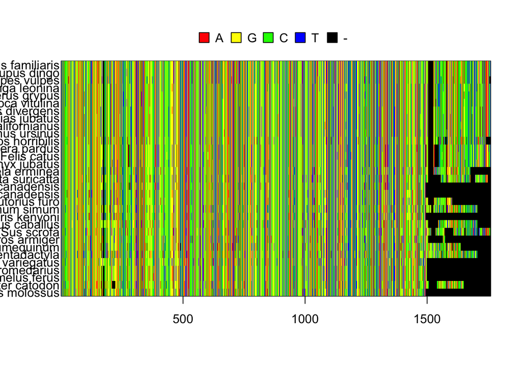

### TH Tree

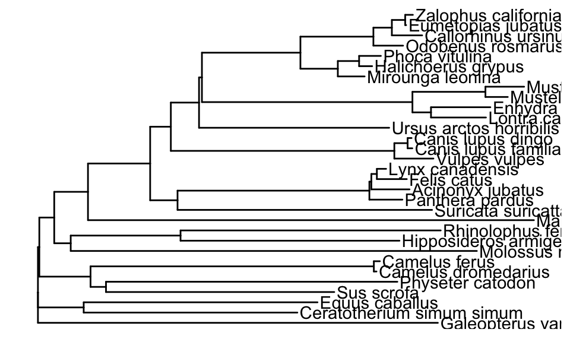

```r
#making a distance matrix based on the alignment
TH_DM <- dist.dna(TH_align)

#making a neighbour joining tree based on distance matrix
TH_Tree <- njs(TH_DM)

#visualizing the tree
TH_treeim <- ggtree(TH_Tree)+
  geom_tiplab()
TH_treeim
```

```r
#saving the tree image
ggsave(filename = "THtree.png", TH_treeim, device = "png", width = 20, height = 4, units = "in" , limitsize = FALSE)

#creating a tree without branch dists
TH_nodist <- ggtree(TH_Tree, branch.length = "none")+
  geom_tiplab()+
  xlim(NA, 24)
#saving no branch dist tree
ggsave(filename = "THtree_nodist.png", TH_nodist, device = "png", width = 8, height = 4, units = "in" , limitsize = FALSE)
```

There are a lot of species deemed by having a similar sequence to the canis lupus familiaris. One possibility for this is that studies have shown that variants of this gene are often repeat variants (Ito et al. 2004; Hejjas et al. 2007). It is possible that these species contain multiple copies of the TH gene - one that is similar to the BLAST-ed sequence from canis lupus familiaris and other copies that may cause behavioural differences.

## Literature Cited

Hejjas K., Kubinyi E., Ronai Z., Szekely A., Vas J., Miklosi A., Sasvari-Szekely M. & Kereszturi E. (2009) Molecular and behavioral analysis of the intron 2 repeat polymorphism in the canine dopamine D4 receptor gene. Genes, Brain and Behavior 8: 330–336.

Ito H., Nara H., Inoue-Murayama M. et al. (2004) Allele frequency distribution of the canine dopamine receptor D4 gene exon III and I in 23 breeds. Journal of Veterinary Medical Science 66: 815– 20.

Malkemper EP, Topinka V, Burda H. (2015). A behavioral audiogram of the red fox (Vulpes vulpes). Hear Res. 320:30-7. doi: 10.1016/j.heares.2014.12.001.

Sadakata, T., Washida, M., Iwayama, Y., Shoji, S., Sato, Y., Ohkura, T., Katoh-Semba, R., Nakajima, M., Sekine, Y., Tanaka, M., Nakamura, K., Iwata, Y., Tsuchiya, K. J., Mori, N., Detera-Wadleigh, S. D., Ichikawa, H., Itohara, S., Yoshikawa, T., & Furuichi, T. (2007). Autistic-like phenotypes in Cadps2-knockout mice and aberrant CADPS2 splicing in autistic patients. The Journal of Clinical Investigation 117: 931–943.

Tovo-Rodrigues L, Rohde LA, Menezes AM, Polanczyk GV, Kieling C, Genro JP, Anselmi L, Hutz MH. (2013). DRD4 rare variants in Attention-Deficit/Hyperactivity Disorder (ADHD): further evidence from a birth cohort study. PLoS One 8:e85164